# State of Open Data 2022 FAIR and CARE analysis

Laurence Horton

12 December, 2022

Research, N., & Goodey, G. (2022). State of Open Data Survey 2022 additional resources (Version 1). figshare. https://doi.org/10.6084/m9.figshare.21295422.v1

### Professional background

**Q2.1 To provide a little more context for your later responses we would first like to understand a little about your research and attitudes towards open science.**

**Q2.2 About you: In which year was your first peer-reviewed research article published?**

**Q2.3 When was the last occasion that you published or submitted a manuscript to a journal?**

**Q2.4 Which type of organisation do you work in?**

**Q2.6 Which of the following job titles best applies to you?**

**Q2.7 Which of the following best describes your primary area of interest?**

**Q2.9 Which country/ territory are you located in?**

**Q2.9_1 Which continent are you located in?**

## Attitudes to Open Science

**Q2.11 To what extent do you agree/disagree with the following statements?**

**Q2.11_1 Making research articles open access should be common scholarly practice**

**Q2.11_2 Making research data openly available should be common scholarly practice (2)**

**Q2.11_3 Making peer review open should be common scholarly practice**

**Q2.11_4 Preprinting should be common scholarly practice**

## Awareness of Open Data principles

**Q3.1_1 How familiar are you with the following data principles in relation to Open Data? FAIR data principles (i.e. Findable, Accessible, Interoperable and Reusable)**

**Q3.1_2 How familiar are you with the following data principles in relation to Open Data? CARE principles for Indigenous Data Governance (i.e. Collective benefit, Authority to control, Responsibility and Ethics)**

## Attitudes towards sharing data

**Do you think researchers currently get sufficient credit for sharing data?**

**Q3.3 What circumstances would motivate you to share your data?**

**Q3.4 Which one of the circumstances would motivate you the most to share your data?**

**Q3.5 What problems/concerns, if any, do you have with sharing datasets? (Please select all that apply)**

**Q3.6 How do you think the data shared by others has or could benefit you? (Please select all that apply)**

## Planning data management

**Q3.7 Are you aware of the concept of a data management plan?**

**Q3.8 To what extent do you feel capable of developing a practical data management plan if you were required to do so?**

**Q3.9 Have you ever created a data management plan?**

**Q3.10 What were the key reasons that led you to creating a data management plan? (Please select all that apply)**

**Q3.11 To what extent did you implement the data management plan for the last project you completed?**

**Q3.12 To what extent have you implemented your data management plan for your current project?**

**Q3.13 What, if any, challenges have you experienced in implementing data management plans? (Please select all that apply)**

**Q3.14 In which, if any, aspects of data management planning do you feel you would benefit from further skills training/information? (Please select all that apply)**

## Collection and curation of research data

**Q3.15 Do you curate/prepare your data for sharing (during or after the data collection process) either privately or publicly?**

**Q3.16 Where do you store your research data while your project is underway? (Please select all that apply)**

**Q3.17 Would you be willing to allow any of the following to help review, curate, or prepare your data for making it publicly available? (Please select all that apply)**

**Q3.18 What areas, if any, do you feel you need help with in regards to managing your research data during the collection period? (Please select all that apply)**

**Q3.19 At which point during the research cycle, if at all, do you make your data available?**

**Q3.20 How do you share your research data with a public audience? (Please select all that apply)**

**Q3.21 To what extent do you think you make your data open in compliance with: [Note: by open we mean free to access, reuse, repurpose and redistribute]**

**Q3.21_1 FAIR data principles (i.e. Findable, Accessible, Interoperable and Reusable)**

**Q3.21_2 CARE principles for Indigenous Data Governance (i.e. Collective benefit, Authority to control, Responsibility and Ethics)**

**Q3.22 To what extent do you think researchers in your field more generally make their data open in compliance with: [Note: by open we mean free to access, reuse, repurpose and redistribute]**

**Q3.22_1 FAIR data principles (i.e. Findable, Accessible, Interoperable and Reusable)**

**Q3.22_2 CARE principles for Indigenous Data Governance (i.e. Collective benefit, Authority to control, Responsibility and Ethics)**

**Q3.23 What recognition have you received for sharing your research data? (Please select all that apply)**

**Q3.24 Have you ever been involved in a collaboration as a result of data you have previously shared?**

**Q3.25 Who would/does meet the costs of making your research data openly accessible (e.g. resource for curation)?**

**Q3.26 To what extent are you comfortable with others using your data for the following?**

**Q3.26_1 Replication studies (use of your data as a reference to determine whether they can be repeated under similar conditions)**

**Q3.26_2 Reanalysis (using a different method to analyse your data set)**

**Q3.26_3 Reinterpretation (using your data as is to answer another question)**

**Q3.26_4 Isolated reuse (reanalysing your data to answer a new question)**

**Q3.26_5 Combination reuse (reanalysing your data in combination with other data sets to answer a new question)**

**Q3.27 What areas, if any, do you feel you need help with in regard to making your research data openly available? (Please select all that apply)**

## Discovery, reuse and citation of Open Data

**Q3.28 Since January 2020, have you reused any of the below as part of your research?: (Please select all that apply) [Note: by ‘reuse’ we mean undertaking new analysis of a pre-existing data set, either on its own or to add to another data set, to answer a different research question to that which the collection of data was originally intended]**

**Q3.29 To what extent has the COVID-19 pandemic affected your reuse of data?** **Q3.29_1 Your own data**

**Q3.29_2 Data shared by other research groups (whether openly or on personal request)**

**Q3.30 Where have you previously obtained research data which has been collected by other research groups, for your own reuse?**

**Q3.31 How would you rate the importance of each of the following with reference to determining the quality of an openly accessible data set? [Note: by open we mean free to access, reuse, repurpose and redistribute]** **Q3.31_1 The data are available from a publicly available repository**

**Q3.31_2 The data are new (e.g. released within the last year)**

**Q3.31_3 The data come from a known source (e.g. familiar institution or academic)**

**Q3.31_4 The data are in a repository that I know checks/curates the data**

**Q3.31_5 The data are associated with a peer-reviewed article**

**Q3.31_6 Data visualisations (e.g. figures, charts) reflect the true state of the source data**

**Q3.31_7 Data is consistent with previously published findings**

**Q3.31_8 The data set is complete for my needs**

**Q3.31_9 Associated metadata give me confidence in the quality of the data**

**Q3.32 Has your request and/or reuse of a dataset ever resulted in a collaboration?**

## Support for researchers and Open Data

**Q3.33 If you required help with managing or making your research data openly available, which sources would you rely upon? (Please select all that apply) [Note: by open we mean free to access, reuse, repurpose and redistribute]**

**Q3.34 Have you ever received any support with planning, managing or sharing your research data?**

**Q3.35 Who did you receive support from? (Please select all that apply)**

**Q3.36 What level of support do you think is available from the following if you needed help in planning, managing or sharing your research data?** **Q3.36_1 Institution/Organisation**  
**Q3.36_2 Funder** **Q3.36_3 Publisher**

**Q3.37 Considering your most recent piece of research, which, if any, of the following have a policy on data sharing? (Please select all that apply)**

**Q3.38 Would you like more guidance on how to comply with the policies of any of the below on making your research data openly available? (Please select all that apply)**

**Q3.39 How supportive would you be of a national mandate for making research data openly available?**

**Q3.40 Should funders make the sharing of research data part of their requirements for awarding grants?**

**Q3.41 Should funders withhold funding from (or penalise in other ways) researchers who do not share their data if the funder has mandated that they do so at the grant application stage?**

**Q3.1_1 How familiar are you with the following data principles in relation to Open Data? FAIR data principles (i.e. Findable, Accessible, Interoperable and Reusable)**

**Q3.1_2 How familiar are you with the following data principles in relation to Open Data? CARE principles for Indigenous Data Governance (i.e. Collective benefit, Authority to control, Responsibility and Ethics)**

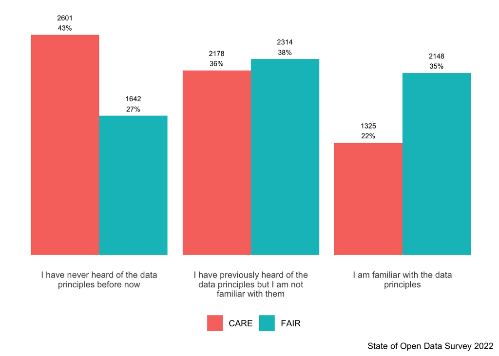

```
## [1] 0.5771458
```

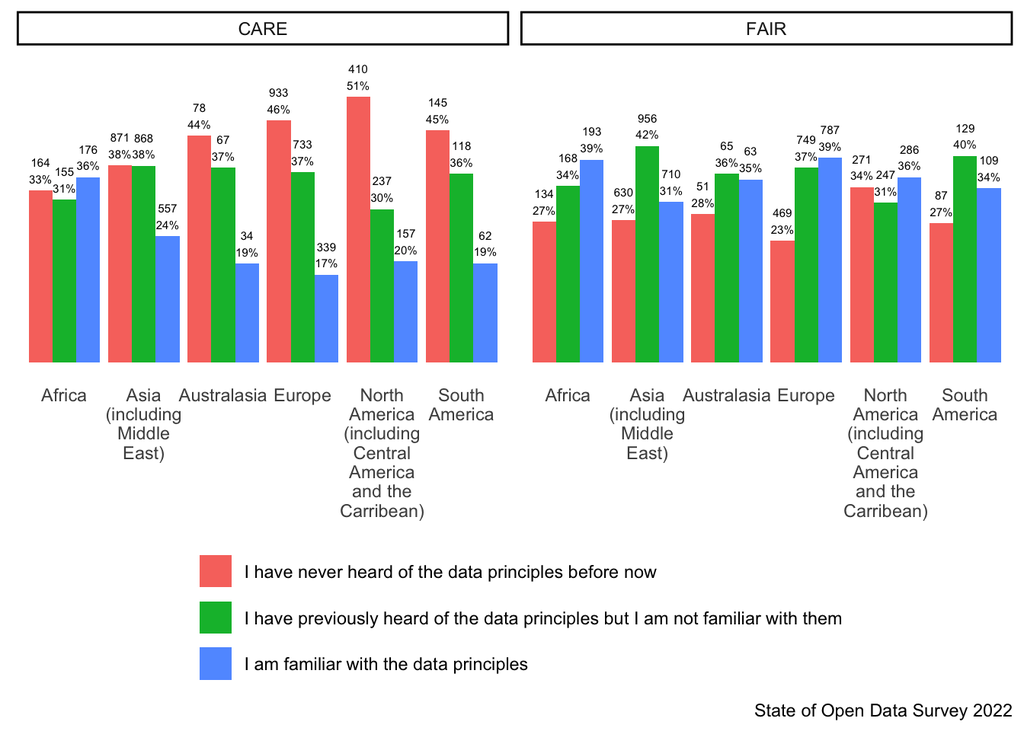

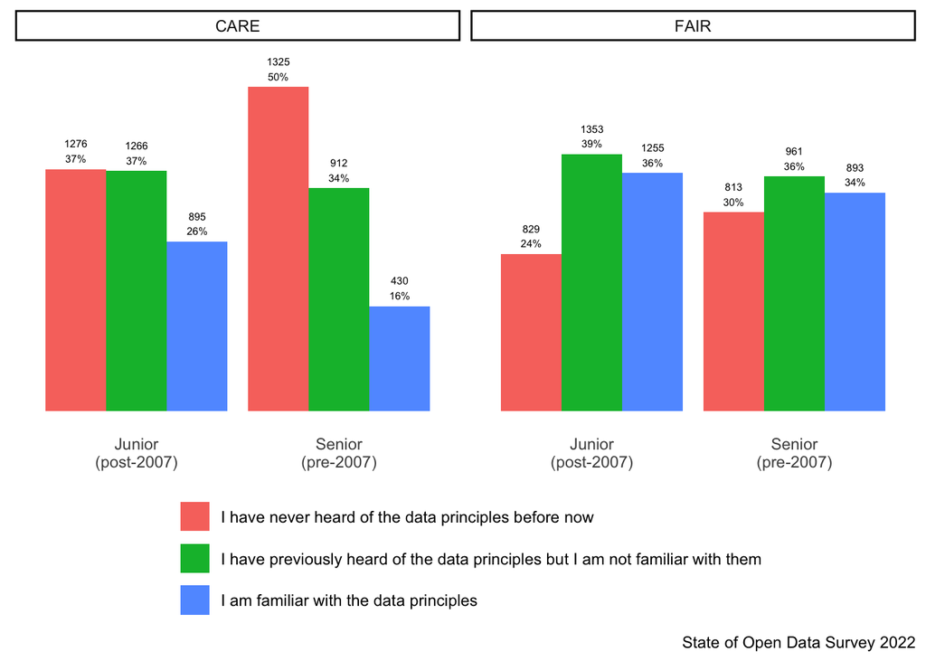

```
## [1] -0.002987628
```

```
## [1] 0.06519647
```

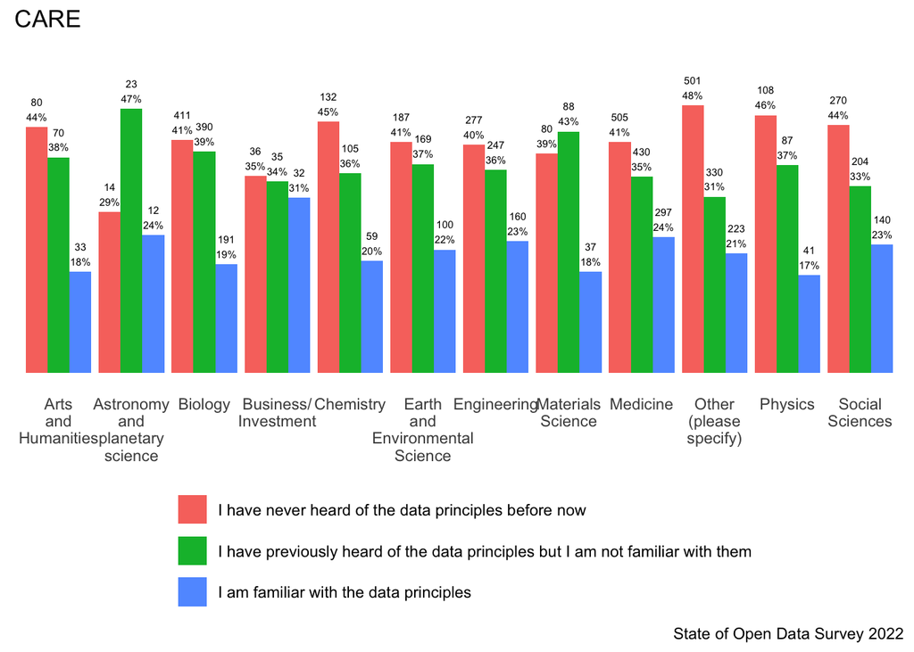

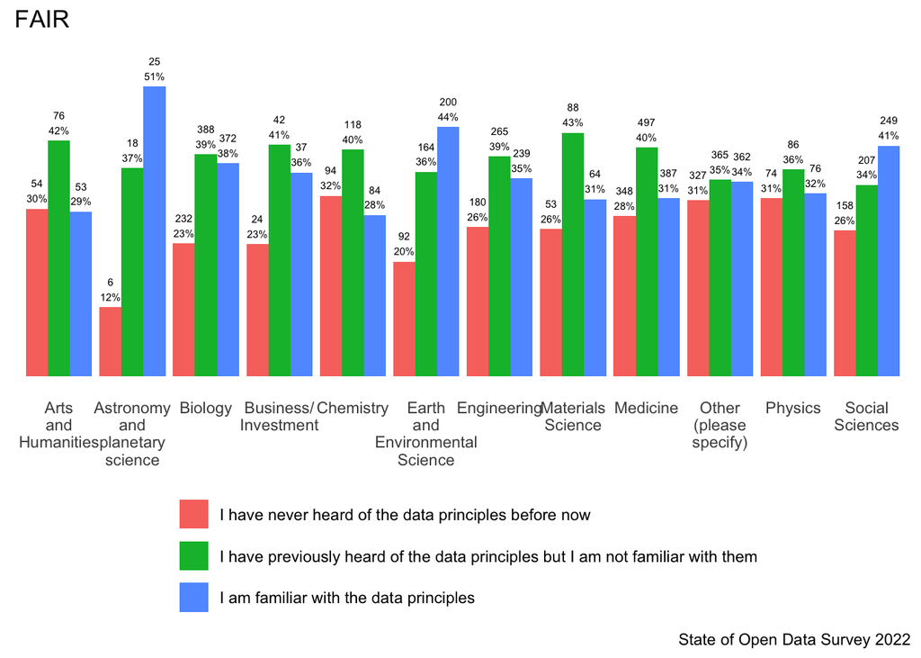

**Q3.21 To what extent do you think you make your data open in compliance with: [Note: by open we mean free to access, reuse, repurpose and redistribute]**

**Q3.21_1 FAIR data principles (i.e. Findable, Accessible, Interoperable and Reusable)**

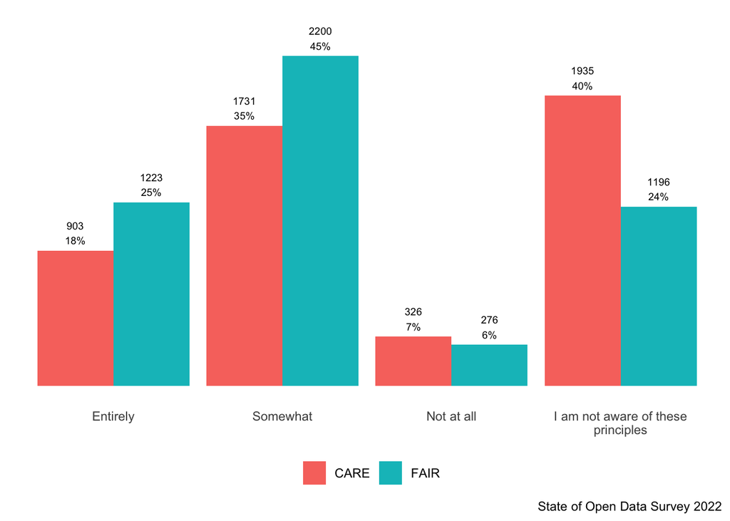

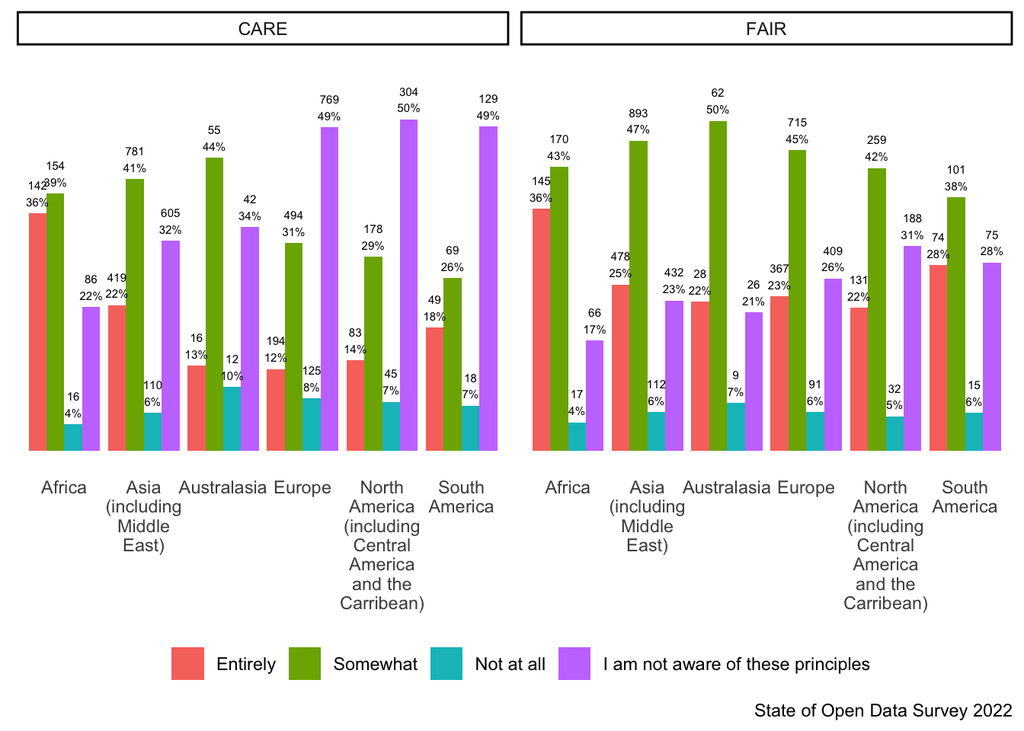

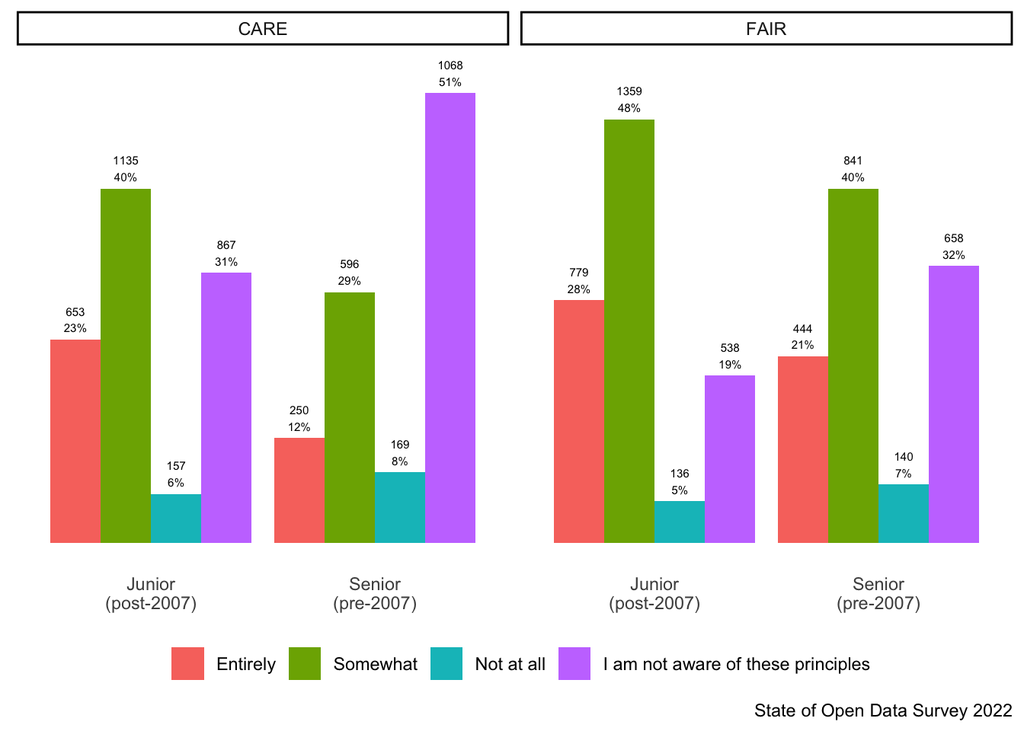

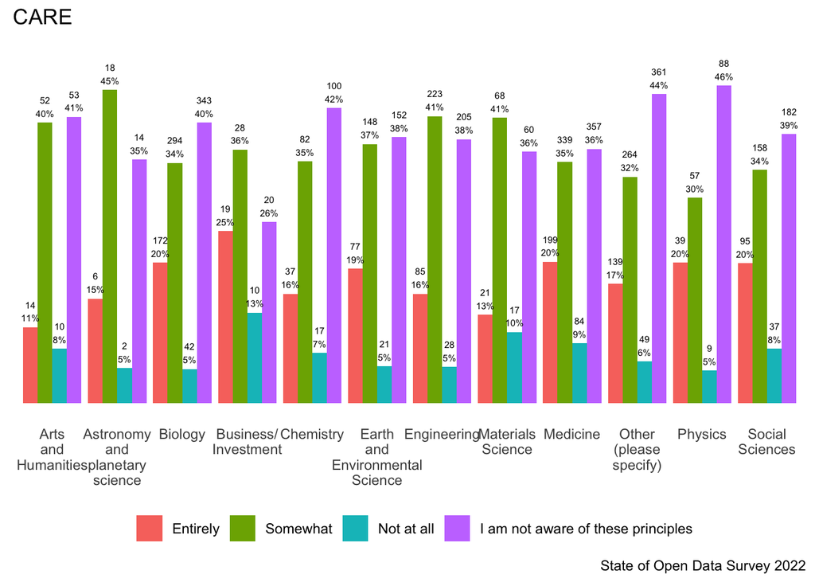

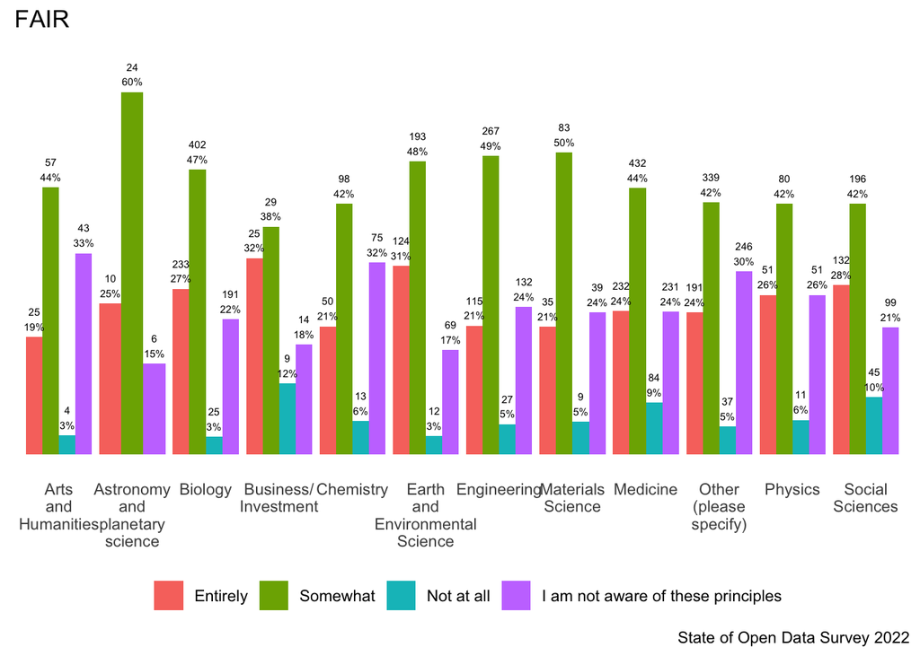

**Q3.22 To what extent do you think researchers in your field more generally make their data open in compliance with: [Note: by open we mean free to access, reuse, repurpose and redistribute]**

**Q3.22_1 FAIR data principles (i.e. Findable, Accessible, Interoperable and Reusable)** **Q3.22_2 CARE principles for Indigenous Data Governance (i.e. Collective benefit, Authority to control, Responsibility and Ethics)**

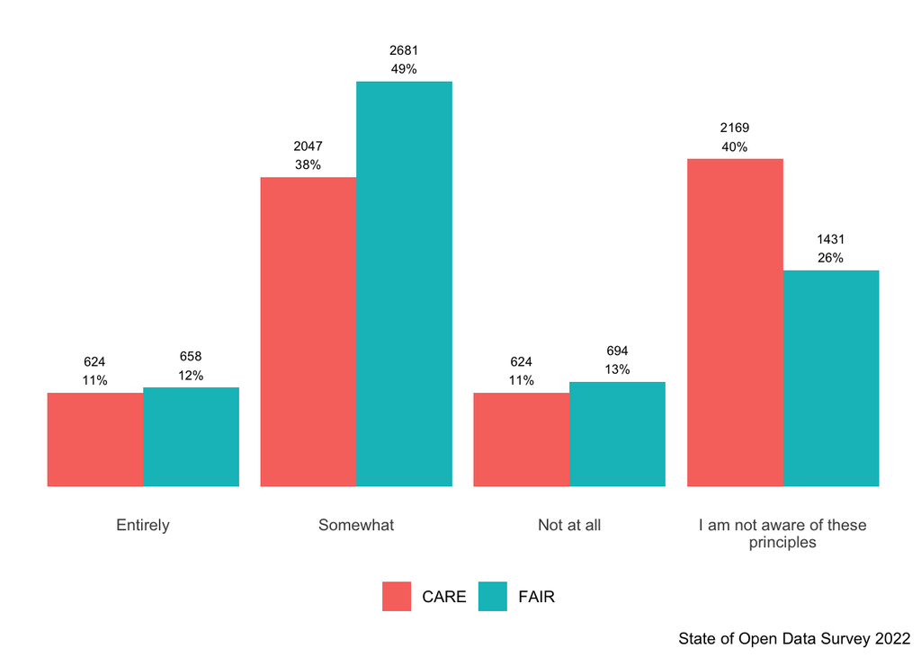

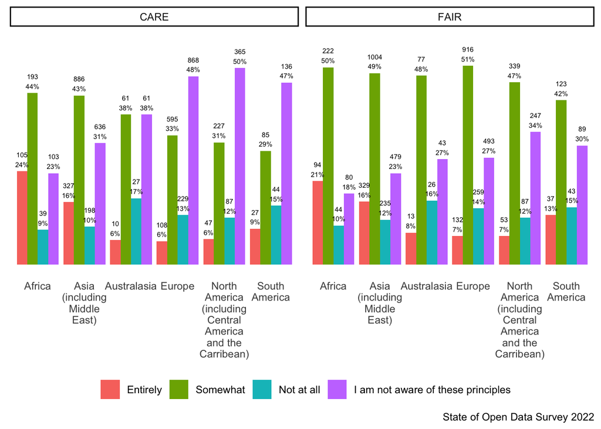

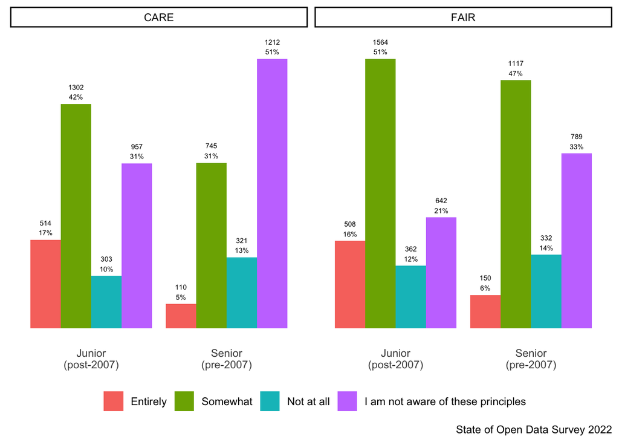

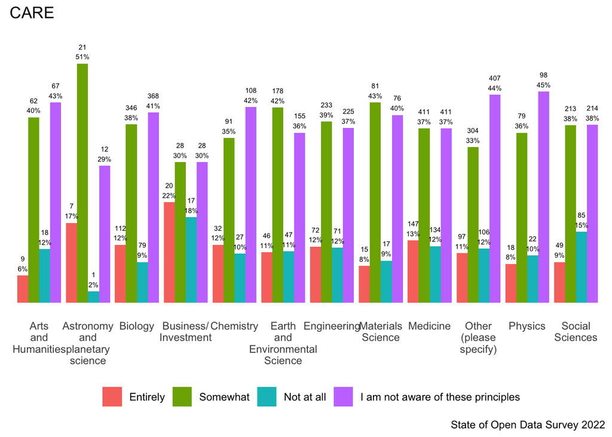

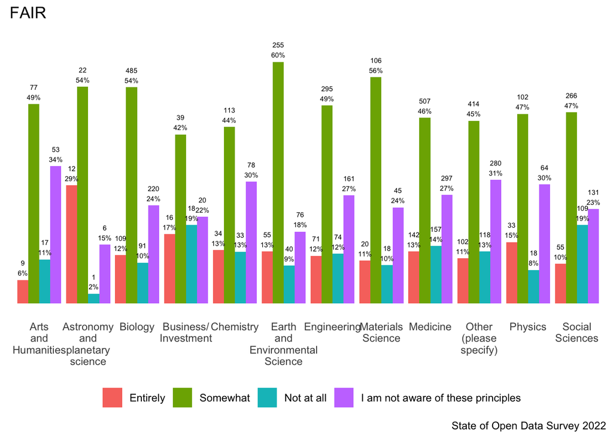

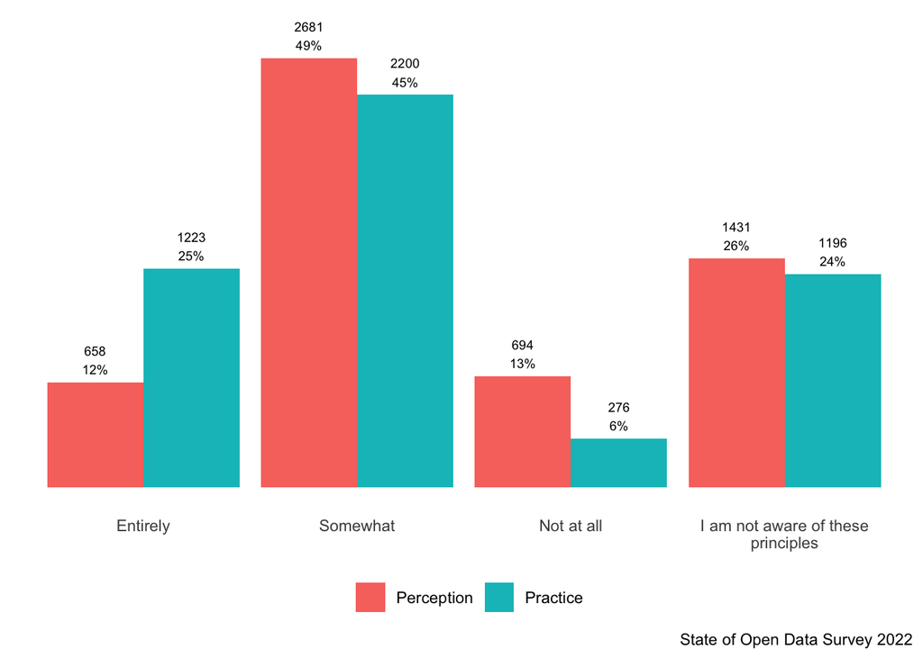

[output not shown]

[output cut: 83 more lines]

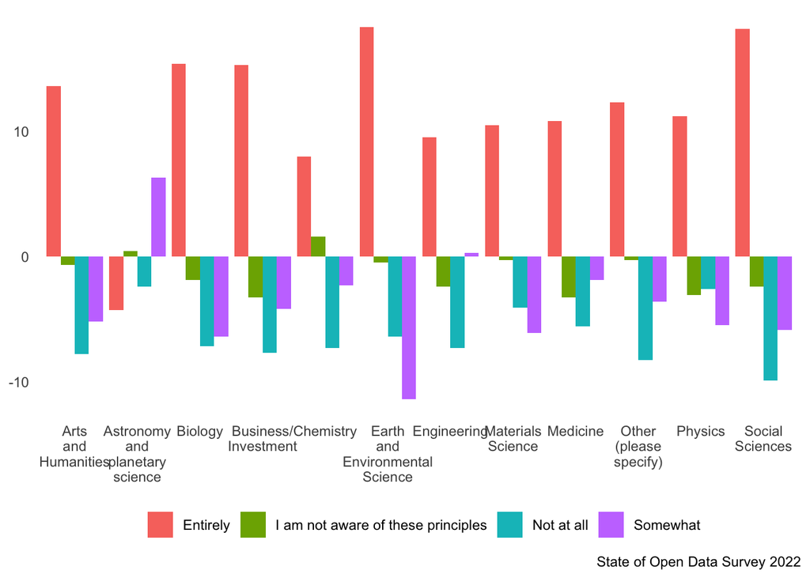